# Denoising using Deep Learning

Train DL models to denoise images.

```python
import pandas as pd
from skimage import io
import matplotlib.pyplot as plt
import numpy as np
import random
import skimage as ski
from skimage import io, transform
import csv
import os
import random
import torch
import torch.nn as nn
from torch.utils.data import Dataset, DataLoader
import torchvision.transforms as transforms
import torch.optim as optim
import sys

sys.path.insert(1, "../../utils")
from utils import NoiseDatsetLoader
```

# Adding Noise in the Images And Creating a Noisy Dataset

```python
def noiseAddtion(image, noiseIndicator):
    # This function gets an image of size m x n. Range of values is (0,1).
    # noiseIndicator is type of noise that needs to be added to the image
    # noiseIndicator == 0 indicates an addition of gaussian noise with mean 0 and var 0.08
    # noiseIndicator == 1 indicates an addition of Salt and Pepper noise with intensity variation of 0.08
    # noiseIndicator == 2 indicates an addition of poisson noise
    # noiseIndicator == 3 indicates an addition of Speckle noise of mean 0 and var 0.05

    ## This function should return a noisy version of the input image

    ##  ***************** Your Code starts here ***************** ##

    m, n = image.shape

    if noiseIndicator == 0:
        # Gaussian noise - val is variance
        # Clip image to range [0.0,1.0]
        noisy = np.clip(image + np.random.normal(0, np.sqrt(0.08), size=(m, n)), 0.0, 1.0)
        return noisy

    elif noiseIndicator == 1:
        # Salt and Pepper noise

        noisy = image.copy()
        noisy = noisy.reshape(-1)

        # Get all indices
        indices = np.linspace(0, (m * n) - 1, m * n, dtype=np.int32)

        # Shuffle indices
        np.random.shuffle(indices)

        # Get num pixels
        num_pixels = int((0.08 / 2) * m * n)

        black_pixels = indices[:num_pixels]
        for index in black_pixels:
            noisy[index] = 0.0

        # Get white pixels
        white_pixels = indices[num_pixels : num_pixels * 2]
        for index in white_pixels:
            noisy[index] = 1.0

        # Reshape image
        noisy = noisy.reshape((m, n))

        return noisy
    elif noiseIndicator == 2:
        # Poisson noise
        noisy = np.clip(np.random.poisson((image * 255).astype(np.int32), size=(m, n)) / 255, 0.0, 1.0)
        return noisy
    elif noiseIndicator == 3:
        # Speckle noise
        noisy = np.clip(image + (image * np.random.normal(0, np.sqrt(0.05), size=(m, n))), 0.0, 1.0)
        return noisy

    return None
```

### Added my functions here to convert to grayscale. Converts all images of faces into grayscale and saves them to the Grayscale folder.

```python
# Returns the num channels for a passed in image np ndarray
def get_num_channels(img):
    # Check for grayscale
    if len(img.shape) < 3:
        return 1

    return img.shape[-1]


# Convert images to grayscale and print shape
def convert_grayscale(image):
    weights = [0.3, 0.6, 0.1]

    channels = get_num_channels(image)
    if channels == 1:  # Grayscale
        return image
    elif channels == 3:  # RGB
        return (image @ weights) * 255
    elif channels == 4:  # ARGB
        # Only use the first 3 channels
        return (image[:, :, :3] @ weights) * 255


for i in range(1000):
    image = plt.imread(f"../../utils/Ross_assignemnt/img_{i}.png")
    # print(image.max())
    # print(image.shape)

    out = convert_grayscale(image)
    # print(out.max())
    # print(out.shape)
    # print()
    io.imsave(f"../../utils/Grayscale/{i}.png", out.astype(np.ubyte))
```

```python
def writeCSV(csv_file_name, Trainingdictlist):
    csv_columns = ["RefImageName", "NoiseType", "NoisyImage"]
    try:
        with open(csv_file_name, "w") as csvfile:
            writer = csv.DictWriter(csvfile, fieldnames=csv_columns)
            writer.writeheader()
            for data in Trainingdictlist:
                writer.writerow(data)
    except IOError:
        print("I/O error")


def createNoisyDataset(root_dir, type, numberOfSamples, noisyIndicatorLow, noisyIndicatorHigh):
    if type == 1:
        name_csv = pd.read_csv("../../utils/file_name_train.csv")
        csv_file_name = "TrainingDataSet.csv"
        directoryName = "TrainingDataset/"
        Trainingdictlist = [dict() for x in range(numberOfSamples)]
        if not os.path.exists(directoryName):
            os.makedirs(directoryName)
    elif type == 0:
        name_csv = pd.read_csv("../../utils/file_name_test.csv")
        csv_file_name = "TestingDataSet.csv"
        directoryName = "TestingDataset/"
        Trainingdictlist = [dict() for x in range(numberOfSamples)]
        if not os.path.exists(directoryName):
            os.makedirs(directoryName)
    elif type == 2:
        # Validation dataset
        name_csv = pd.read_csv("../../utils/file_name_validation.csv")
        csv_file_name = "ValidationDataSet.csv"
        directoryName = "ValidationDataset/"
        Trainingdictlist = [dict() for x in range(numberOfSamples)]
        if not os.path.exists(directoryName):
            os.makedirs(directoryName)

    for i in range(numberOfSamples):
        r2 = random.randint(0, len(name_csv) - 1)  # Choose an image randomly from the dataset
        # Read the image from a path
        img_name = os.path.join(root_dir, name_csv.iloc[r2, 0])
        image = io.imread(img_name)

        # Normalize the image to range (0,1)
        M, N = image.shape
        maximumPixelValue = np.max(image)
        minimumPixelValue = np.min(image)
        rangeOfPixelValues = maximumPixelValue - minimumPixelValue
        if rangeOfPixelValues > 0.0:
            image = (image - minimumPixelValue) / rangeOfPixelValues

        # Choosing the noise randomly
        r1 = random.randint(2, 3)
        # create and clip the noisy image [0,1]
        noisyImage = np.clip(noiseAddtion(image, r1), 0.0, 1.0)

        Trainingdictlist[i] = {"RefImageName": img_name, "NoiseType": r1, "NoisyImage": str(i) + ".png"}

        io.imsave(directoryName + str(i) + ".png", (maximumPixelValue * noisyImage + minimumPixelValue).astype(np.ubyte))

    writeCSV(csv_file_name, Trainingdictlist)
```

## The function below calls the above function to create a noisy training and testing dataset.

Don't worry about lossy conversion warnings.

```python
createNoisyDataset("../../utils/GrayScale", 1, 400, 0, 5)  ## Creating 400 samples of Training Data
createNoisyDataset("../../utils/GrayScale", 0, 200, 0, 5)  ## Creating 200 samples of Training Data
createNoisyDataset("../../utils/GrayScale", 2, 200, 0, 5)  ## Creating 200 samples of Validation Data
```

## Visualize Samples of Each of the noise Type here Using any plotting library

```
0
0
197
203
```

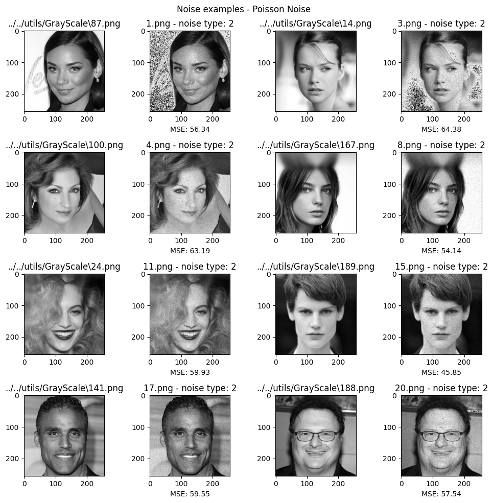

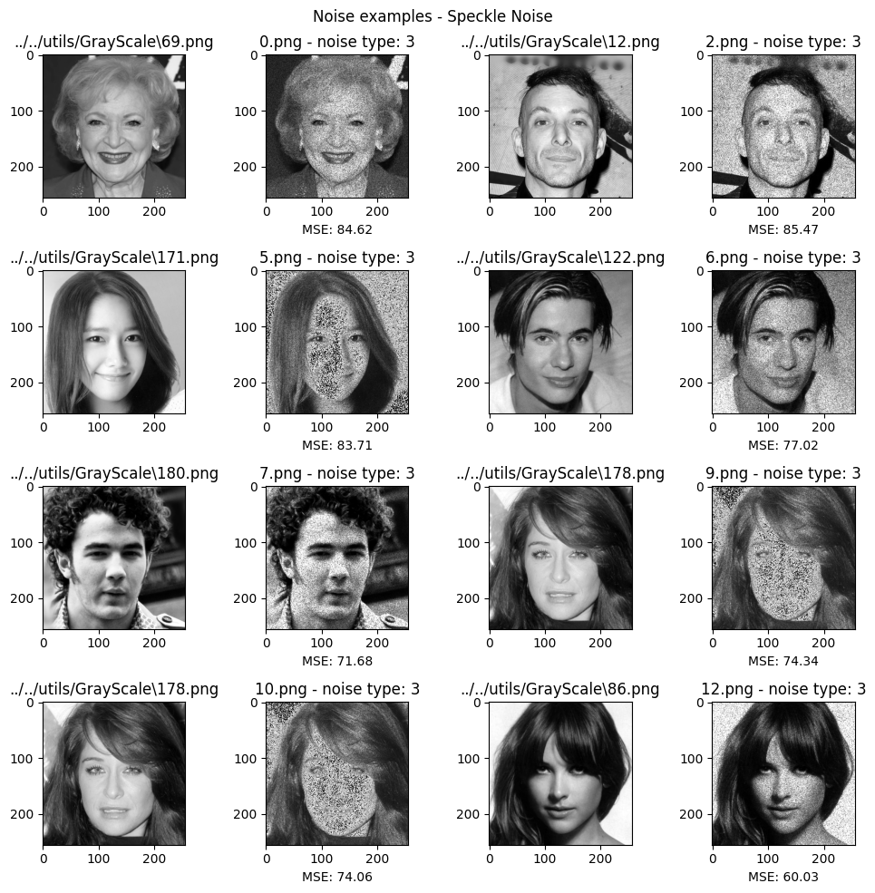

```python
## Your Code Starts here
def mean_squared_error(a, b):
    return (((a - b) ** 2).sum()) / (a.shape[0] * a.shape[1])


training_set = pd.read_csv("./TrainingDataSet.csv")

# Get samples of each type of noise from training set
samples_0 = []
samples_1 = []
samples_2 = []
samples_3 = []
for i in range(training_set.shape[0]):
    noise_type = training_set.loc[i]["NoiseType"]

    if noise_type == 0:
        samples_0.append(training_set.loc[i])
    elif noise_type == 1:
        samples_1.append(training_set.loc[i])
    elif noise_type == 2:
        samples_2.append(training_set.loc[i])
    elif noise_type == 3:
        samples_3.append(training_set.loc[i])


print(len(samples_0))
print(len(samples_1))
print(len(samples_2))
print(len(samples_3))


def display_noise(data, axs):
    original_name = data["RefImageName"]
    noise_name = data["NoisyImage"]
    noise_type = data["NoiseType"]

    orig_image = io.imread(original_name)
    noise_image = io.imread(f"./TrainingDataset/{noise_name}")

    axs[0].imshow(orig_image, cmap="gray")
    axs[1].imshow(noise_image, cmap="gray")

    axs[0].set_title(original_name)
    axs[1].set_title(f"{noise_name} - noise type: {noise_type}")

    axs[1].set_xlabel(f"MSE: {mean_squared_error(orig_image, noise_image).round(2)}")
    return


def display_noise_samples(imgs_data, suptitle):
    rows = len(imgs_data) // 2
    cols = 4
    fig, axs = plt.subplots(rows, cols, figsize=(10, 10))
    for i, ax in enumerate(axs):
        idx = i * 2

        if idx < len(imgs_data):
            display_noise(imgs_data[idx], ax[:2])

        if idx + 1 < len(imgs_data):
            display_noise(imgs_data[idx + 1], ax[2:])

    plt.suptitle(f"Noise examples - {suptitle}")
    plt.tight_layout()
    # plt.savefig(f'{OUT_PATH}/correlations-{suptitle}.png')


# display_noise_samples(samples_0[:8], "Gaussian Noise")
# display_noise_samples(samples_1[:8], "Salt and Pepper Noise")
display_noise_samples(samples_2[:8], "Poisson Noise")
display_noise_samples(samples_3[:8], "Speckle Noise")

## Your Code ends here
```

```python
del samples_0
del samples_1
del samples_2
del samples_3
```

```python
import gc

gc.collect()
```

```
90107
```

- Poisson noise is very subtle in some of the images and stronger in other parts of the image. The MSE is still quite high so you can see the noise in the image.
- The speckle noise is quite strong and you can see it in all the images. While the Poisson noise was more subtle, this noise is very noticeable in all images at the current intensity.

# Neural Network for Denoising

We now have a noisy training set and a reference images.

```python
dtype = torch.float32  ## instialize the data types used in training
cpu = torch.device("cuda:0" if torch.cuda.is_available() else "cpu")
print(cpu)

# Reproducibility
torch.manual_seed(32)
random.seed(32)
np.random.seed(32)
```

```
cuda:0
```

## Complete the Training Function Below

Looked at the PyTorch docs to get a better understand of the training loop.

```python
def trainingLoop(dataloader, model, optimizer, nepochs, val_dataloader):
    ## This function Trains your model for 'nepochs'
    ## Using optimizer and model your passed as arguments
    ## On the data present in the DataLoader class passed
    ##
    ## This function return the final loss values
    ##
    ## you could pass in the validation training set as well in order to compute validation error

    model = model.to(device=cpu)

    ## Our Loss function for this exercise is fixed to MSELoss
    loss_function = nn.MSELoss()
    loss_array = []
    epoch_loss_array = []
    epoch_validation_loss_array = []

    for e in range(nepochs):
        print("Epoch", e)
        model.train()
        current_loss_arr = []
        curr_validation_loss_arr = []

        for t, temp in enumerate(dataloader):
            # print(t)

            ## Before Training Starts, put model in Training Mode
            # model.train()
            NoisyImage = temp["NoisyImage"].to(device=cpu, dtype=dtype)
            referenceImage = temp["image"].to(device=cpu, dtype=dtype)

            ## Pass your input images through the model
            ## Be sure to set the gradient as Zero in Optmizer before backward pass. Hint:- zero_grad()
            ## Step the otimizer on after backward pass
            ## calcualte the loss value using the ground truth and the output image1
            ## Assign the value computed by the loss function to a varible named 'loss'

            # Running image thru model
            out = model(NoisyImage)

            # Calculate loss
            loss = loss_function(out, referenceImage)

            # Backprop using loss
            loss.backward()

            # for param in model.parameters():
            #     print(param.grad)

            # Update optimizer
            optimizer.step()

            optimizer.zero_grad()

            ## Due to dataset being Gray you may have to use unsqueeze function here
            loss_val = loss.cpu().detach().unsqueeze(0).numpy()
            loss_array.append(loss_val)
            current_loss_arr.append(loss_val)

        # Validation step
        model.eval()
        for t, temp in enumerate(val_dataloader):
            NoisyImage = temp["NoisyImage"].to(device=cpu, dtype=dtype)
            referenceImage = temp["image"].to(device=cpu, dtype=dtype)

            # Running image thru model
            out = model(NoisyImage)

            # Calculate loss
            loss = loss_function(out, referenceImage)

            ## Due to dataset being Gray you may have to use unsqueeze function here
            loss_val = loss.cpu().detach().unsqueeze(0).numpy()
            curr_validation_loss_arr.append(loss_val)

        # Only print every 10 plz
        # if e % 10 == 0:
        #     print(f'Epoch {e} - Training loss: {np.mean(current_loss_arr)}')

        print("Training loss: ", np.mean(current_loss_arr))
        print("Validation loss: ", np.mean(curr_validation_loss_arr))

        # Track mean loss over epoch
        epoch_loss_array.append(np.mean(current_loss_arr))
        epoch_validation_loss_array.append(np.mean(curr_validation_loss_arr))
        # print("Average loss for epoch: ", np.mean(current_loss_arr))

        # here you could turn on eval mode and compute/print/graph the validation error

    return loss, epoch_loss_array, epoch_validation_loss_array
```

```python
TrainingSet = NoiseDatsetLoader(csv_file="TrainingDataSet.csv", root_dir_noisy="TrainingDataset")
TestingSet = NoiseDatsetLoader(csv_file="TestingDataSet.csv", root_dir_noisy="TestingDataset")
ValidationSet = NoiseDatsetLoader(csv_file="ValidationDataSet.csv", root_dir_noisy="ValidationDataset")

## Batch Size is a hyper parameter, You may need to play with this paramter to get a more better network
## This is a user controlled parameter you can change this value
batch_size = 16

## DataLoader is a pytorch Class for iterating over a dataset
dataloader_train = DataLoader(TrainingSet, batch_size=batch_size, num_workers=4)
dataloader_test = DataLoader(TestingSet, batch_size=1)
dataloader_val = DataLoader(ValidationSet, batch_size=1)
```

## Model 1

- Declare a model with one conv2d filter with 1 input channel and output channel

```python
## Declare your Model/Models in the space below
## You should try atleast 4-5 different models.
## You can start with a linear model if you want, but it's not reqiured.  If you do a linear model, you need only one layer (multiple layers don't help) but you might need bigger kernels 7x7 or up to 11x11.  Experiment.
## You should try several models that have conv2d layers and nonlinear activations.  Try expanding the number of features and number of layers.  Do 3 or 4 layers help (better results)?
## You should have a couple of networks that downsample (e.g. maxpooling) and upsample to produce the final output.  No need for fully connected layers.  Is this better than the architectures above.

ksize = 7
model = torch.nn.Sequential(
    torch.nn.Conv2d(
        in_channels=1,
        out_channels=1,
        kernel_size=(ksize, ksize),
        padding=ksize // 2,
        padding_mode="zeros",
    ),
    torch.nn.ReLU(),
)

model
```

```
Sequential(
  (0): Conv2d(1, 1, kernel_size=(7, 7), stride=(1, 1), padding=(3, 3))
  (1): ReLU()
)
```

```python
## Set your hypter parameters
learningRate = 1e-3  # Set this value between 1e-2 to 1e-4
weightDecay = 1e-3  # Set this value between 1e-2 to 1e-4

epochs = 200  # Start with 50 or 100 and can experiment with value as high as 300-400.

## Optimizer
## Please Declare An Optimizer for your model. We suggest you use SGD
## ************* Start of your Code *********************** ##

optimizer = torch.optim.SGD(model.parameters(), lr=learningRate, weight_decay=weightDecay)

## ************ End of your code ********************   ##
```

```python
## Train Your Model. Complete the implementation of trainingLoop function above
valMSE, train_loss, val_loss = trainingLoop(dataloader_train, model, optimizer, epochs, dataloader_val)
# you could put this in a loop over epochs and test error after each epoch,
# or you can modify this to take validation data and print validation error as it goes.
```

```
Epoch 0
Training loss:  0.27658546
Validation loss:  0.2599092
Epoch 1
Training loss:  0.2742331
Validation loss:  0.25595093
Epoch 2
Training loss:  0.24516176
Validation loss:  0.16374424
Epoch 3
Training loss:  0.10846801
Validation loss:  0.05400859
Epoch 4
Training loss:  0.040029254
Validation loss:  0.02328447
Epoch 5
Training loss:  0.02123682
Validation loss:  0.015335037
Epoch 6
Training loss:  0.01622135
Validation loss:  0.013359789
Epoch 7
Training loss:  0.014883269
Validation loss:  0.01290094
Epoch 8
Training loss:  0.014519111
Validation loss:  0.012806494
Epoch 9
Training loss:  0.014411357
Validation loss:  0.012788954
Epoch 10
Training loss:  0.014370527
Validation loss:  0.012781675
Epoch 11
Training loss:  0.014346922
Validation loss:  0.012771938
Epoch 12
Training loss:  0.014327645
Validation loss:  0.012758925
Epoch 13
```

[output cut: 545 more lines]

```
Epoch 195
Training loss:  0.012159575
Validation loss:  0.0106248045
Epoch 196
Training loss:  0.01215167
Validation loss:  0.010617123
Epoch 197
Training loss:  0.012143792
Validation loss:  0.010609465
Epoch 198
Training loss:  0.012135941
Validation loss:  0.010601835
Epoch 199
Training loss:  0.012128115
Validation loss:  0.01059423
```

### Plot the graph of loss vs epoch

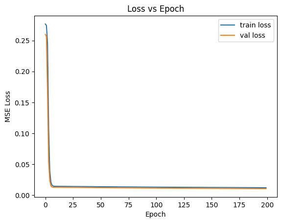

```python
## ************* Start of your Code *********************** ##

plt.plot(range(epochs), train_loss, label="train loss")
plt.plot(range(epochs), val_loss, label="val loss")
plt.legend()
plt.ylabel("MSE Loss")
plt.xlabel("Epoch")
plt.title("Loss vs Epoch")

## ************ End of your code ********************   ##
```

```python
# Save the model
torch.save(model, "./models/model1.pt")
model = torch.load("./models/model1.pt")
```

## Complete the Accuracy Function Below

```python
def checkTestingAccuracy(dataloader, model):
    ## This Function Checks Accuracy on Testing Dataset for the model passed
    ## This function should return the loss the Testing Dataset

    ## Before running on Testing Dataset the model should be in Evaluation Mode

    model.eval()
    totalLoss = []
    loss_mse = nn.MSELoss()
    for t, temp in enumerate(dataloader):
        NoisyImage = temp["NoisyImage"].to(device=cpu, dtype=dtype)
        referenceImage = temp["image"].to(device=cpu, dtype=dtype)

        ## For Each Test Image Calculate the MSE loss with respect to Reference Image
        ## Return the mean the total loss on the whole Testing Dataset
        ## ************* Start of your Code *********************** ##

        out = model(NoisyImage)

        loss = loss_mse(out, referenceImage)

        totalLoss.append(loss.cpu().detach().unsqueeze(0).numpy())

        ## ************ End of your code ********************   ##

    return np.mean(totalLoss)
```

```python
## Test Your Model. Complete the implementation of checkTestingAccuracy function above
model.eval()
testMSE = checkTestingAccuracy(dataloader_test, model)
print("Mean Square Error for the testing Set for the trained model is ", testMSE)
```

```
Mean Square Error for the testing Set for the trained model is  0.009135539
```

## Plot some of the Testing Dataset images by passing them through the trained model

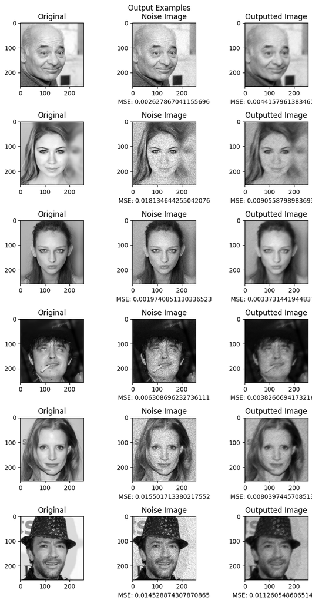

```python
## ************* Start of your Code *********************** ##


def display_out(data, axs):
    orig_image = data[0]
    noise_image = data[1]
    out_image = data[2]

    axs[0].imshow(orig_image, cmap="gray")
    axs[0].set_title("Original")

    axs[1].imshow(noise_image, cmap="gray")
    axs[1].set_title("Noise Image")
    axs[1].set_xlabel(f"MSE: {mean_squared_error(orig_image, noise_image)}")

    axs[2].imshow(out_image, cmap="gray")
    axs[2].set_title("Outputted Image")
    axs[2].set_xlabel(f"MSE: {mean_squared_error(orig_image, out_image)}")

    return


def display_output_images(m):
    # Get images to display from test set
    noise_images = []
    orig_images = []
    out_images = []
    num_images = 6

    m.eval()
    for t, temp in enumerate(dataloader_test):
        if t >= num_images:
            break

        NoisyImage = temp["NoisyImage"].to(device=cpu, dtype=dtype)
        referenceImage = temp["image"].to(dtype=dtype)

        out = m(NoisyImage)

        noise_images.append(NoisyImage.cpu().detach().squeeze())
        orig_images.append(referenceImage.squeeze())
        out_images.append(out.cpu().detach().squeeze())

    rows = len(noise_images)
    cols = 3
    fig, axs = plt.subplots(rows, cols, figsize=(8, 14))
    for i, ax in enumerate(axs):
        orig_image = orig_images[i]
        noise_image = noise_images[i]
        out_image = out_images[i]

        display_out([orig_image, noise_image, out_image], ax)

    plt.suptitle(f"Output Examples")
    plt.tight_layout()
    # plt.savefig(f'{OUT_PATH}/correlations-{suptitle}.png')


display_output_images(model)


## ************ End of your code ********************   ##
```

## Comment on the Denoised image Obtained

This simple model with only 1 Conv2d layer with kernel size of 7 and 0 padding, and a ReLU nonlinearity does a decent job at denoising the image. You can see that for most of the images, the outputted image has a lower MSE as compared to the noise image. Visually the outputted image is slightly darker and slightly more blurred in this case. Certain details are not as well defined. But surprisingly it does do a somewhat decent job of removing the obvious noise from the image.

# Model 2

- experiment with other models architectures, including more (or less) layers, more hidden nodes, etc.

```python
## ************* Start of your Code *********************** ##

ksize = 7
model2 = torch.nn.Sequential(
    torch.nn.Conv2d(
        in_channels=1,
        out_channels=1,
        kernel_size=(ksize, ksize),
        padding=ksize // 2,
        padding_mode="zeros",
    ),
    torch.nn.ReLU(),
    torch.nn.Conv2d(
        in_channels=1,
        out_channels=1,
        kernel_size=(ksize, ksize),
        padding=ksize // 2,
        padding_mode="zeros",
    ),
    torch.nn.ReLU(),
    torch.nn.Conv2d(
        in_channels=1,
        out_channels=1,
        kernel_size=(ksize, ksize),
        padding=ksize // 2,
        padding_mode="zeros",
    ),
    torch.nn.ReLU(),
)

model2
## ************ End of your code ********************   ##
```

```
Sequential(
  (0): Conv2d(1, 1, kernel_size=(7, 7), stride=(1, 1), padding=(3, 3))
  (1): ReLU()
  (2): Conv2d(1, 1, kernel_size=(7, 7), stride=(1, 1), padding=(3, 3))
  (3): ReLU()
  (4): Conv2d(1, 1, kernel_size=(7, 7), stride=(1, 1), padding=(3, 3))
  (5): ReLU()
)
```

```python
## Set your hypter parameters
learningRate = 1e-3  # Set this value between 1e-2 to 1e-4
weightDecay = 1e-3  # Set this value between 1e-2 to 1e-4

epochs = 100  # Start with 50 or 100 Can experiment with maximum 200 or 400 iterations

## Optimizer
## Please Declare An Optimizer for your model. We suggest you use SGD
## ************* Start of your Code *********************** ##

optimizer = optim.SGD(model2.parameters(), lr=learningRate, weight_decay=weightDecay)

## ************ End of your code ********************   ##
```

```python
valMSE, train_loss, val_loss = trainingLoop(dataloader_train, model2, optimizer, epochs, dataloader_val)
```

```
Epoch 0
Training loss:  0.280739
Validation loss:  0.2640251
Epoch 1
Training loss:  0.28071603
Validation loss:  0.26400405
Epoch 2
Training loss:  0.2806839
Validation loss:  0.26397336
Epoch 3
Training loss:  0.2806349
Validation loss:  0.2639237
Epoch 4
Training loss:  0.2805496
Validation loss:  0.2638281
Epoch 5
Training loss:  0.28034905
Validation loss:  0.2635254
Epoch 6
Training loss:  0.27822083
Validation loss:  0.25501534
Epoch 7
Training loss:  0.21276155
Validation loss:  0.11260956
Epoch 8
Training loss:  0.059949435
Validation loss:  0.025914302
Epoch 9
Training loss:  0.02493086
Validation loss:  0.022667203
Epoch 10
Training loss:  0.023714663
Validation loss:  0.022324247
Epoch 11
Training loss:  0.023335919
Validation loss:  0.021968398
Epoch 12
Training loss:  0.02296812
Validation loss:  0.021611089
Epoch 13
```

[output cut: 245 more lines]

```
Epoch 95
Training loss:  0.014015412
Validation loss:  0.013041602
Epoch 96
Training loss:  0.013983538
Validation loss:  0.013010897
Epoch 97
Training loss:  0.013952063
Validation loss:  0.012980588
Epoch 98
Training loss:  0.013920975
Validation loss:  0.012950662
Epoch 99
Training loss:  0.013890264
Validation loss:  0.012921117
```

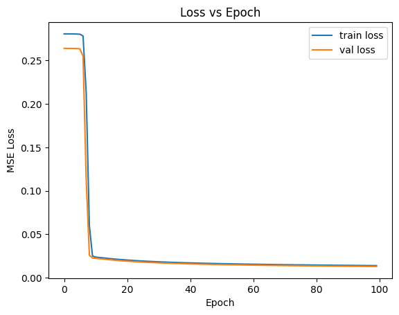

```python
plt.plot(range(epochs), train_loss, label="train loss")
plt.plot(range(epochs), val_loss, label="val loss")
plt.legend()
plt.ylabel("MSE Loss")
plt.xlabel("Epoch")
plt.title("Loss vs Epoch")
```

```python
# Save the model
torch.save(model2, "./models/model2.pt")
model2 = torch.load("./models/model2.pt")
```

```python
## Test Your Model
model2.eval()
testMSE = checkTestingAccuracy(dataloader_test, model2)
print("Mean Square Error for the testing Set for the trained model is ", testMSE)
```

```
Mean Square Error for the testing Set for the trained model is  0.01172842
```

## Plot some of the Testing Dataset images by passing them through the trained model

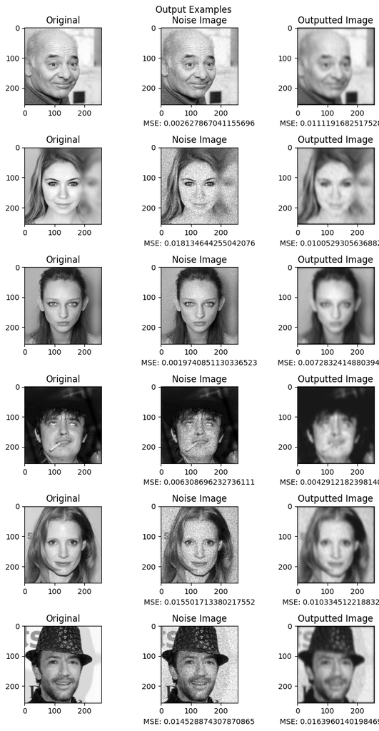

```python
## ************* Start of your Code *********************** ##

display_output_images(model2)

## ************ End of your code ********************   ##
```

The output from model 2 is slightly worse than model 1. It is more blurry and looks like a larger averaging filter with the end result of the image. In 3 of the output images it did output an image that had a lower MSE than the lower image.